# second week: Introduction to R and Rstudio

Mobile Data

Mobin Asri 93101938

2018-02-20 04:41:26

```r
setwd("~/Course-Data-Analysis/Week2/")
options(stringsAsFactors = FALSE)

library(readr)
library(ggplot2)
library(dplyr)

mobile_data=read_csv("Data/mobile_data.csv")
```

۱. کدام شرکت بیشترین تعداد گوشی را تولید کرده است؟ نمودار ستونی ۲۰ شرکت برتر بر حسب تعداد گوشی تولید کرده را رسم کنید.

همان طور که از هیستوگرام زیر مشخص است در طول سال های گذشته شرکت سامسونگ و پس از آن ال جی بیشترین تعداد گوشی ها را ساخته اند.

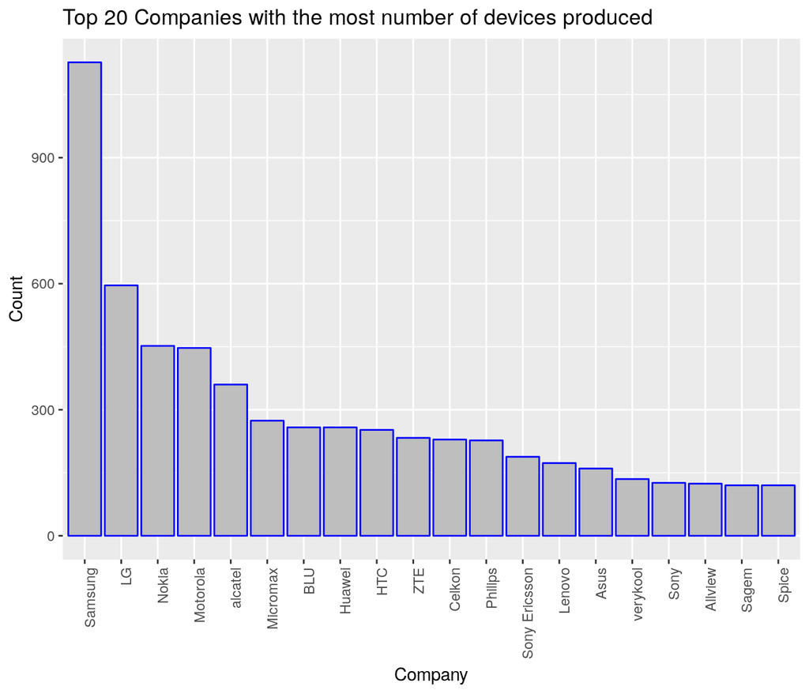

```r
Mobile_Number=table(mobile_data$company)
Mobile_Number=sort(Mobile_Number,decreasing = T)
Mobile_Number=as.data.frame(Mobile_Number[1:20])

ggplot(data = Mobile_Number,aes(x=Var1,y=Freq))+
  geom_bar(stat = "identity",color="blue",fill="gray")+
  xlab("Company")+ylab("Count")+
  ggtitle("Top 20 Companies with the most number of devices produced")+
  theme(axis.text.x = element_text(angle = 90, hjust = 1))
```

۲. نمودار زمانی طول عرض ضخامت و کیفیت دوربین گوشی ها را بکشید و به نمودار هر یک مدل خطی اضافه کنید.

نمودار زمانی ضخامت:

همان طور که مشخص است به صورت کلی در طول زمان ضخامت گوشی ها کاهش یافته است.

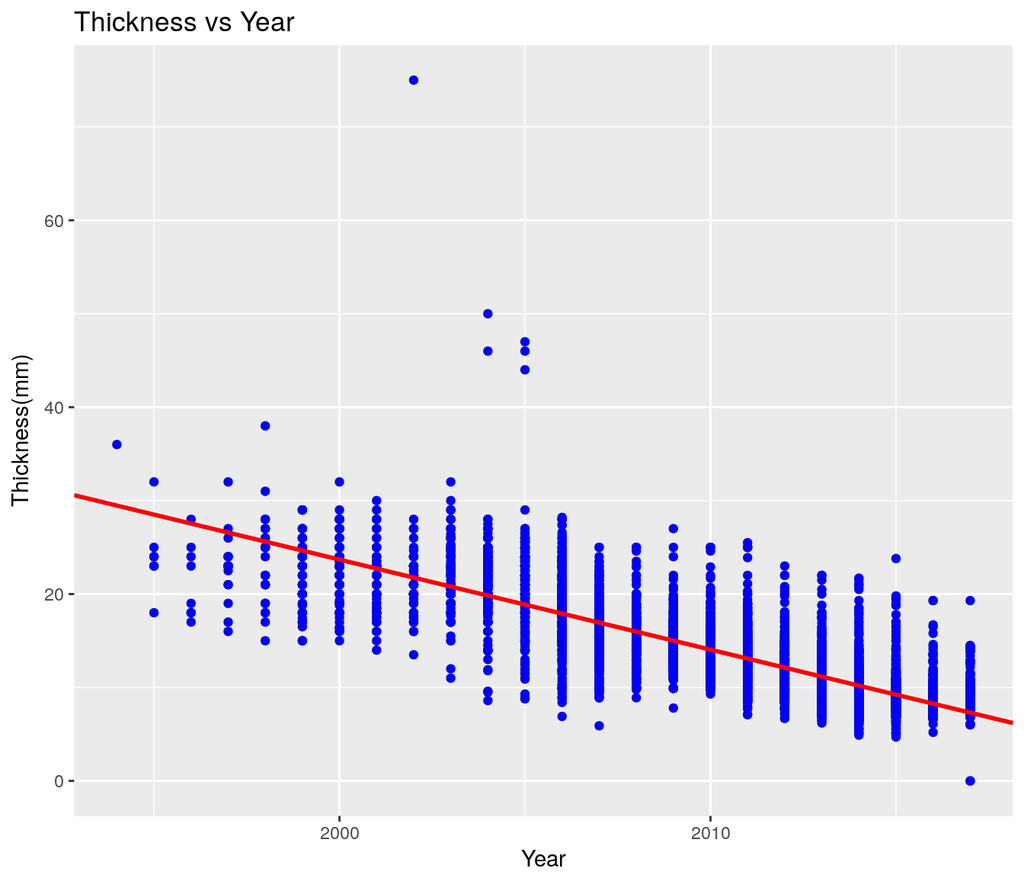

```r
p = ggplot(data = mobile_data ,aes(x=year , y= dim_thickness))
coef=coef(lm(dim_thickness~year,data=mobile_data))
p+geom_point(col="blue")+geom_abline(intercept = coef[1] , slope = coef[2] , color="red" , size = 1)+
  ylab("Thickness(mm)")+xlab("Year")+
  ggtitle("Thickness vs Year")
```

نمودار زمانی طول:

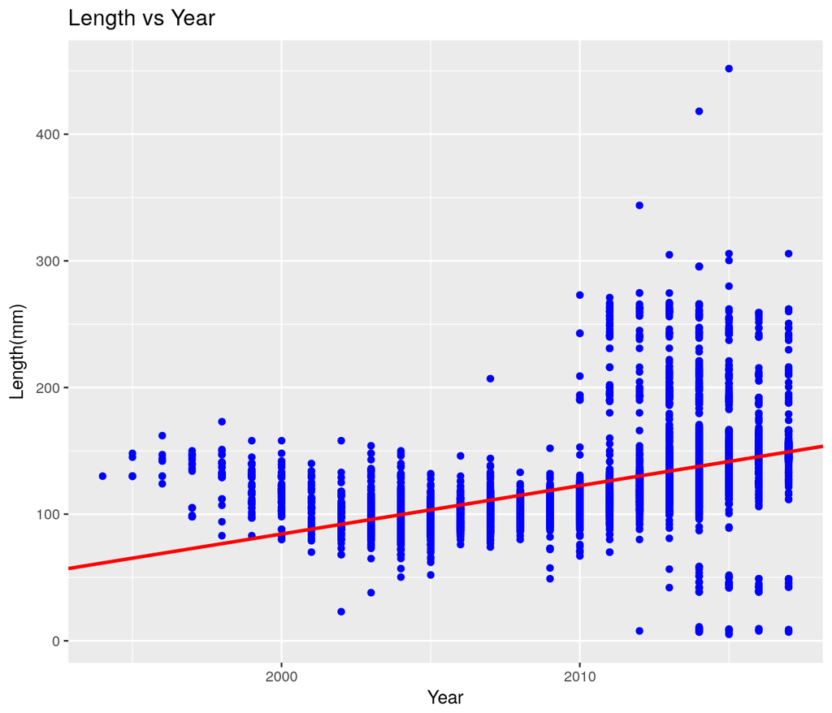

```r
p = ggplot(data = mobile_data ,aes(x=year , y= dim_length))
coef=coef(lm(dim_length~year,data=mobile_data))
p+geom_point(col="blue")+geom_abline(intercept = coef[1] , slope = coef[2] , color="red" , size = 1)+
  ylab("Length(mm)")+xlab("Year")+
  ggtitle("Length vs Year")
```

نمودار زمانی عرض:

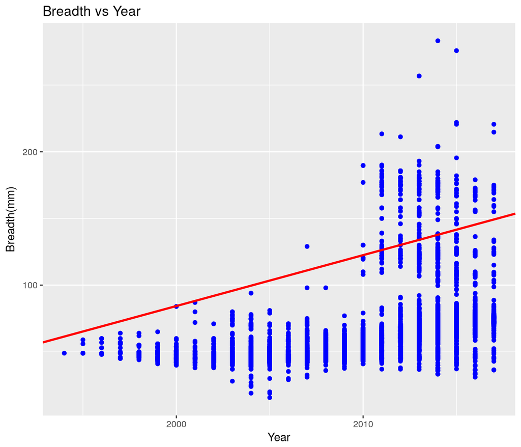

```r
p = ggplot(data = mobile_data ,aes(x=year , y= dim_breadth))
coef=coef(lm(dim_length~year,data=mobile_data))
p+geom_point(col="blue")+geom_abline(intercept = coef[1] , slope = coef[2] , color="red" , size = 1)+
  ylab("Breadth(mm)")+xlab("Year")+
  ggtitle("Breadth vs Year")
```

نمی توان گفت به طول کلی عرض و طول گوشی ها افزایش یافته است. گوشی های با سایز کوچک همچنان تولید می شوند از طرف دیگر تولید گوشی های با سایز بزرگ در حال افزایش هست البته در نمودار های رسم شده تبلت ها نیز در نظر گرفته شده اند.

نمودار زمانی پیکسل دوربین:

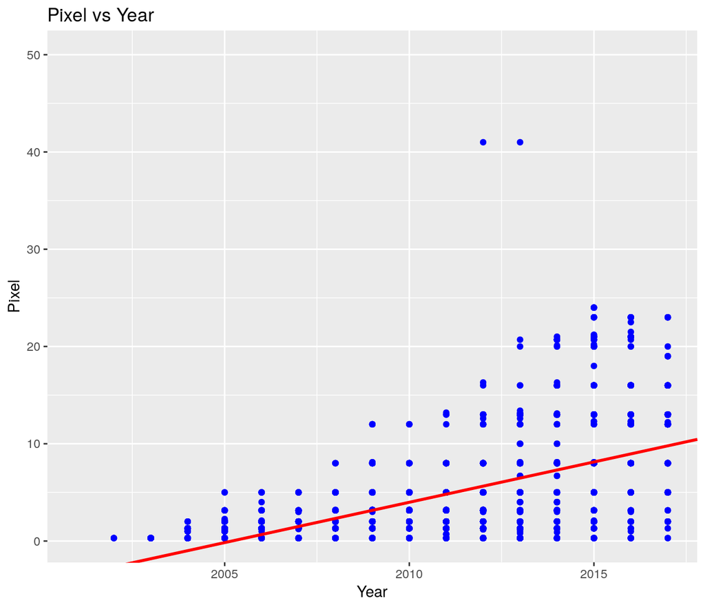

```r
p = ggplot(data = mobile_data ,aes(x=year , y= cam_px))
coef=coef(lm(cam_px~year,data=mobile_data))
p+geom_point(color="blue")+geom_abline(intercept = coef[1] , slope = coef[2] , color="red" , size = 1)+
  ylab("Pixel")+xlab("Year")+
  ggtitle("Pixel vs Year")+xlim(c(2001,2017))
```

گوشی های با کیفیت دوربین پایین همچنان تولید می شوند ولی تولید گوشی های با دوربین های قدرتمند نیز در حال افزایش است همین امر باعث شده تا شیب خط فیت شده مثبت باشد.

۳. نمودار ستونی متوسط قیمت گوشی بر حسب تعداد سیم کارت و دسترسی به LTE را رسم نمایید.

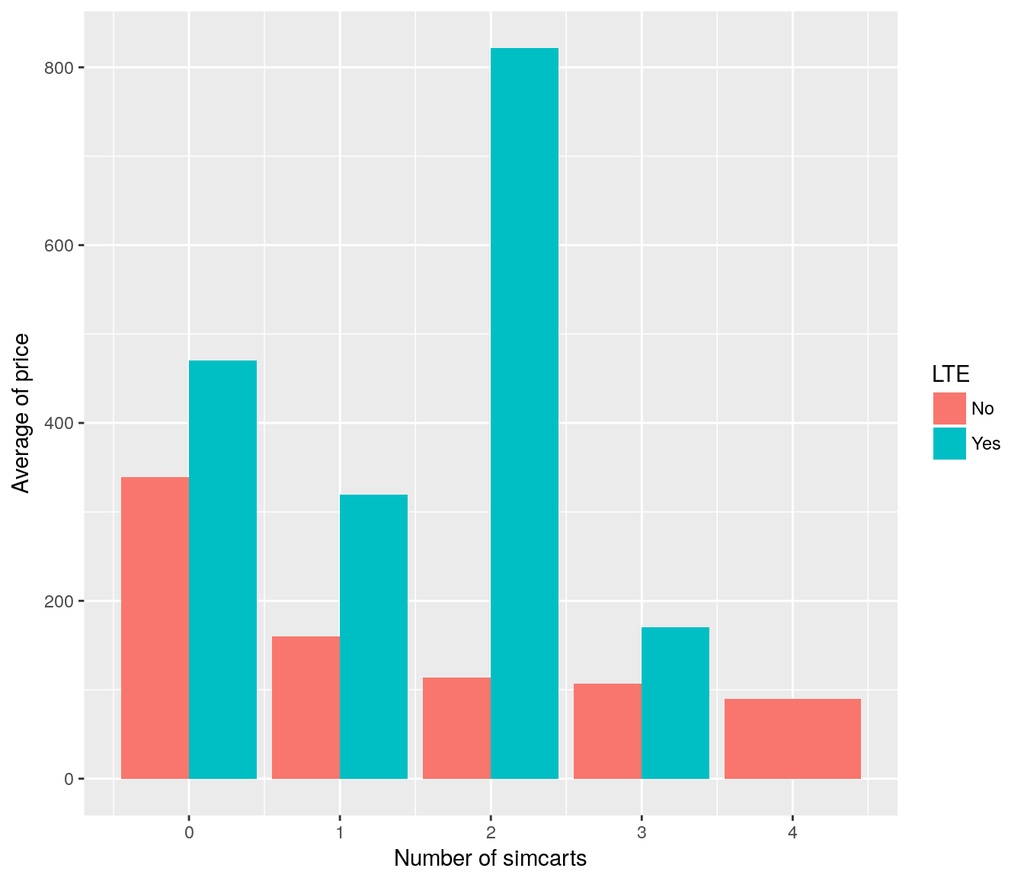

```r
mobile_data %>%
  group_by(sim_no,LTE) %>%
  summarise(average=mean(price,na.rm = T)) -> stat

p=ggplot(stat,aes(x=sim_no,y=average))
p+geom_bar(aes(fill=LTE),position = "dodge",stat="identity")+
  xlab("Number of simcarts")+ylab("Average of price")
```

به طور کلی گوشی های دارای تکنولوژي LTE دارای قیمت های بالاتری نسبت به گوشی هایی که این قابلیت را ندارند می باشد.

۴. نمودار جعبه ایی ضحامت گوشی هایی که در سال ۲۰۱۷ معرفی شده اند را برحسب اینکه کمیت جک هدفون رسم نمایید

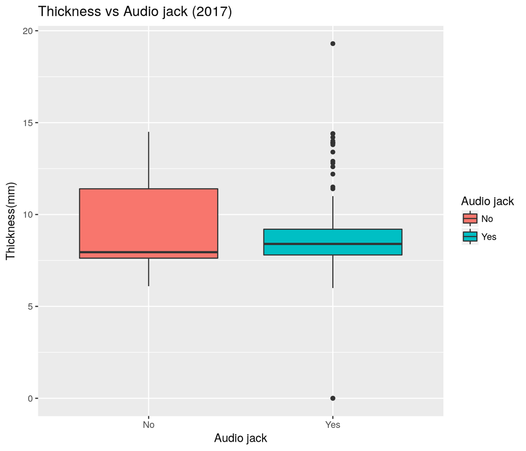

```r
idx_na=!is.na(mobile_data$year) & !is.na(mobile_data$audio_jack)
case=mobile_data[idx_na,]

idx_2017=(case$year==2017)
mobile_data_2017=case[idx_2017,]

p=ggplot(data=mobile_data_2017,aes(x=audio_jack,y=dim_thickness,fill=audio_jack))
p+geom_boxplot()+ylab("Thickness(mm)")+
  xlab("Audio jack")+ggtitle("Thickness vs Audio jack (2017)")+
  guides(fill=guide_legend(title="Audio jack"))
```

۵. مفهوم ppi را در گوشی های موبایل محاسبه و هیستوگرام آن را رسم نمایید. همچنین نمودار سالانه متوسط این کمیت را بکشید. کدام گوشی بیشترین ppi را دارد؟

ppi مخخف pixel per inch است. که معیاری است برای میزان وضوح صفحه نمایش گوشی.

ppi از تقسیم کردن تعداد پیکسل های روی قطر اصلی گوشی بر روی اندازه قطر اصلی به واحد اینچ محاسبه می شود.

$$ppi = \frac{DiagPixel}{DiagLength(inch)}$$
$$DiagPixel=\sqrt{HorizontalPixel^2+VerticalPixel^2}$$

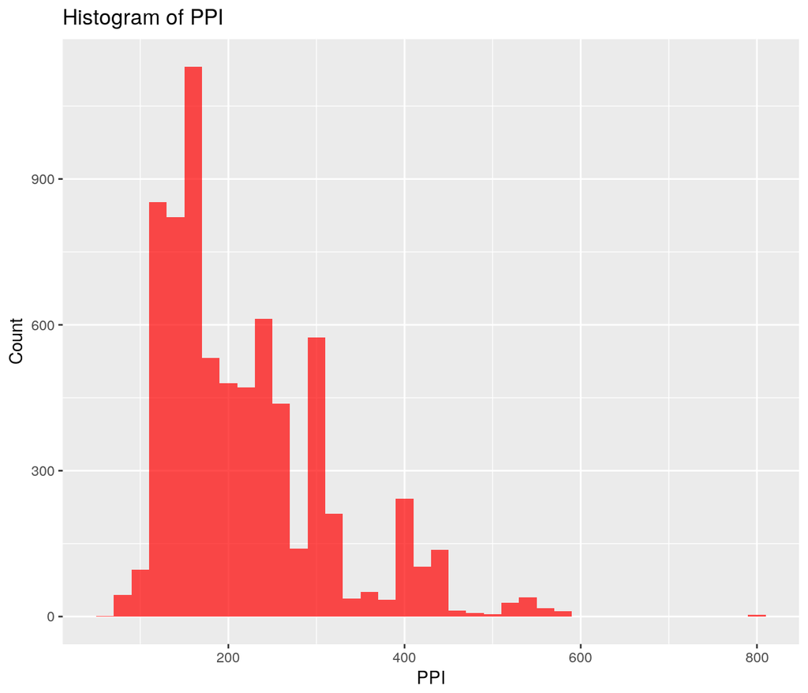

```r
idx_na=!is.na(mobile_data$dim_length) & !is.na(mobile_data$dim_breadth) & !is.na(mobile_data$year)&
  !is.na(mobile_data$px_col) & !is.na(mobile_data$px_row)

case=mobile_data[idx_na,]

case$ppi=sqrt(case$px_col^2+case$px_row^2)/case$display_size

p=ggplot(data=case , aes(x=ppi))
p+geom_histogram(binwidth = 20,fill="red",alpha=0.7)+ylab("Count")+
  xlab("PPI")+ggtitle("Histogram of PPI")
```

```r
case[which.max(case$ppi),c("company","device")]
```

```
## # A tibble: 1 x 2
##   company            device
##     <chr>             <chr>
## 1    Sony Xperia XZ Premium
```

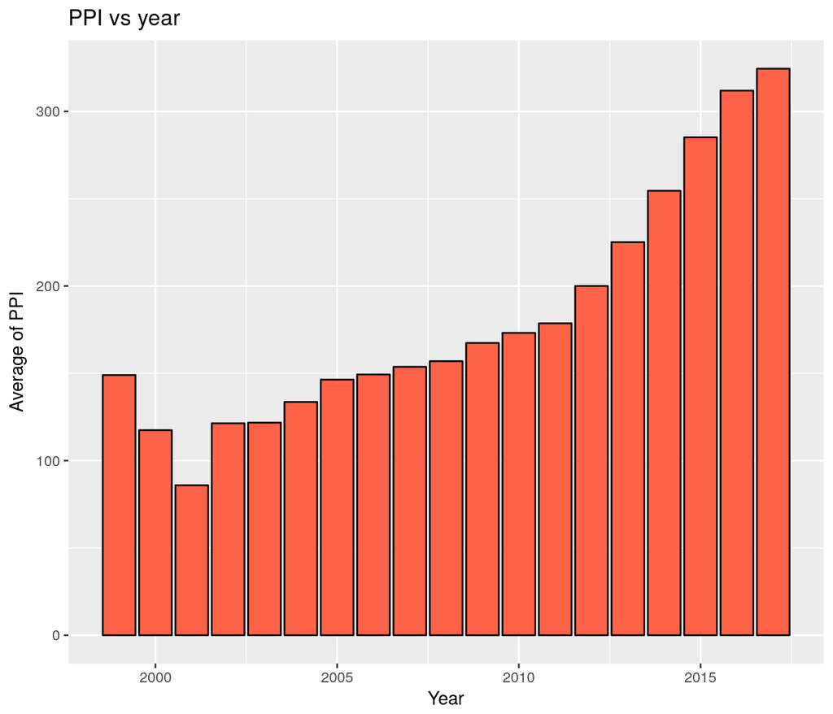

```r
case %>%
  group_by(year) %>%
  summarise(average=mean(ppi,na.rm = T)) -> stat


p=ggplot(data=stat,aes(x=year,y=average))
p+geom_bar(stat="identity",color="black", fill="tomato")+
  ylab("Average of PPI")+
  xlab("Year")+ggtitle("PPI vs year")
```

۶. در گذشته به بعضی از مدل های گوشی نوکیا **گوشکوب** گفته می شد. سعی کنید برای این مفهوم کمیتی مناسب تعریف کنید . ده گوشکوب برتر را پیدا کرده و نمودار گوشکوبیت آن را رسم نمایید.

کمیت مناسب برای اندازه گیری میزان گوشکوبیت گوشی ها از ضرب جرم به گرم و ضخامت به میلی متر حاصل شده است.

همچنین تنها گوشی هایی که اندازه صفحه آنها کمتر از 2 اینچ بوده اند بررسی شده اند.

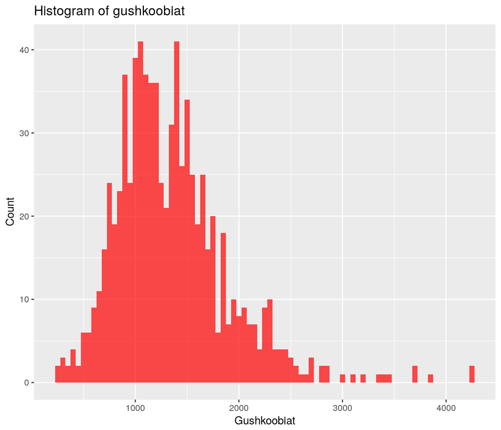

```r
idx_na=!is.na(case$display_size)
case=mobile_data[idx_na,]

idx_size=case$display_size < 2
case=case[idx_size,]

case$gushkoobiat=case$dim_thickness* case$weight

p=ggplot(data=case , aes(x=gushkoobiat))
p+geom_histogram(binwidth = 50,fill="red",alpha=0.7)+ylab("Count")+
  xlab("Gushkoobiat")+ggtitle("Histogram of gushkoobiat")
```

```r
case_gushkoob=case_gushkoob[order(case_gushkoob$gushkoobiat,decreasing = T),]

topTen_gushkoob=case_gushkoob[1:10,]
topTen_gushkoob[,c("company","device")]
```

```
## # A tibble: 10 x 2
##      company           device
##        <chr>            <chr>
##  1     Sonim XP3.20 Quest Pro
##  2     Sonim     XP3.20 Quest
##  3 Icemobile            Acqua
##  4  Motorola             V980
##  5  Motorola             V975
##  6     Sonim       XP3 Enduro
##  7  Motorola             C980
##  8  Motorola             C975
##  9   Thuraya          SG-2520
## 10  Motorola             V635
```

دو نمونه از گوشکوب ترین گوشی های پیداشده:

```
## Sonim: Quest pro 5
```

[figure not shown]

```
## Icemobile: Acqua
```

[figure not shown]

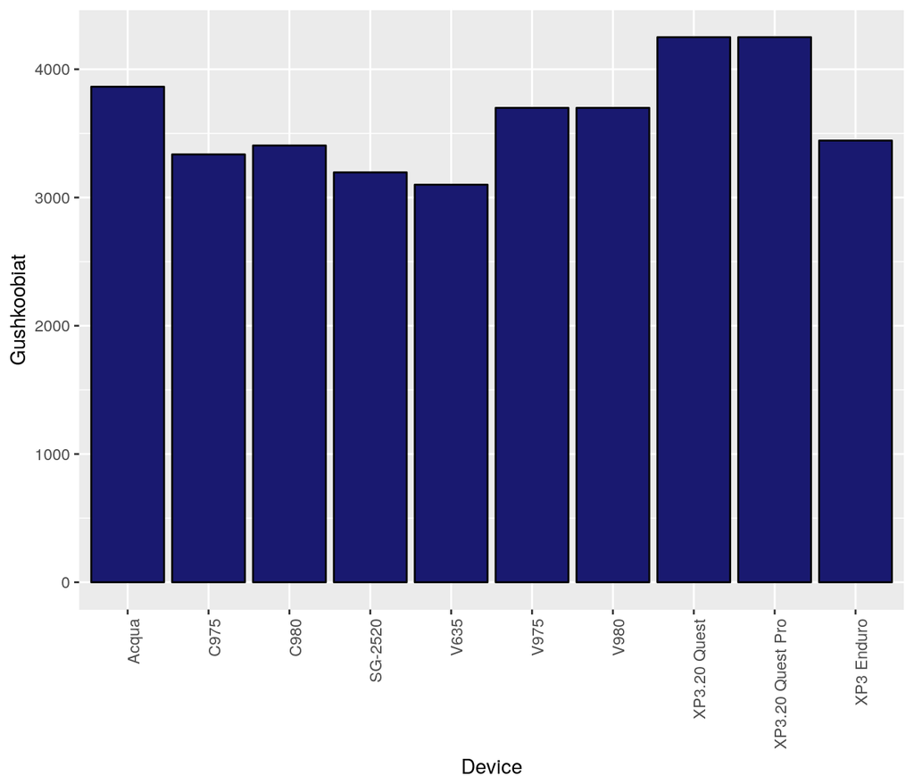

```r
p=ggplot(data=topTen_gushkoob,aes(y=gushkoobiat,x=device))
p+geom_bar(stat="identity",colour="black",fill="midnightblue")+
  xlab("Device")+ylab("Gushkoobiat")+
  theme(axis.text.x = element_text(angle = 90, hjust = 1))
```

۷. آیا تلفن همراهی وجود دارد که در آب غرق نشود؟ اگر جواب بله هست تمام گوشی های که این خاصیت را دارند بیابید. با کشیدن یک نمودار به این سوال پاسخ دهید.

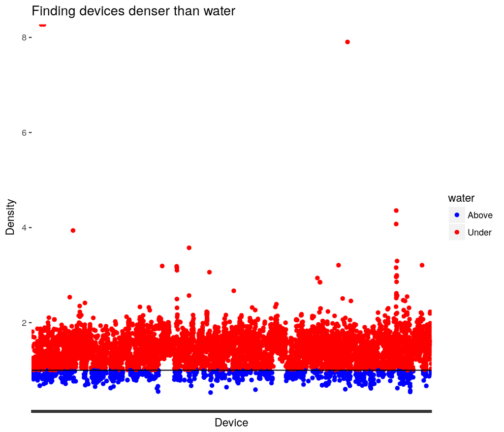

```r
mobile_data$Volume=mobile_data$dim_breadth*mobile_data$dim_length*mobile_data$dim_thickness
mobile_data$Volume=mobile_data$Volume/1000

mobile_data$density=mobile_data$weight/mobile_data$Volume

idx_water=mobile_data$density>1
mobile_data$water="Above"
mobile_data$water[idx_water]="Under"

p=ggplot(data=mobile_data,aes(x=device,y=density))
p+geom_point(aes(colour=water))+theme(axis.text.x=element_blank())+
  xlab("Device")+ylab("Density")+
  ggtitle("Finding devices denser than water")+
  geom_hline(yintercept=1)+
  scale_color_manual(values=c("blue", "red"))
```

۸. نمودار پراکنش حجم ذخیره سازی باطری و وزن را رسم نمایید. میزان همبستگی بین این دو کمیت را محاسبه کنید.

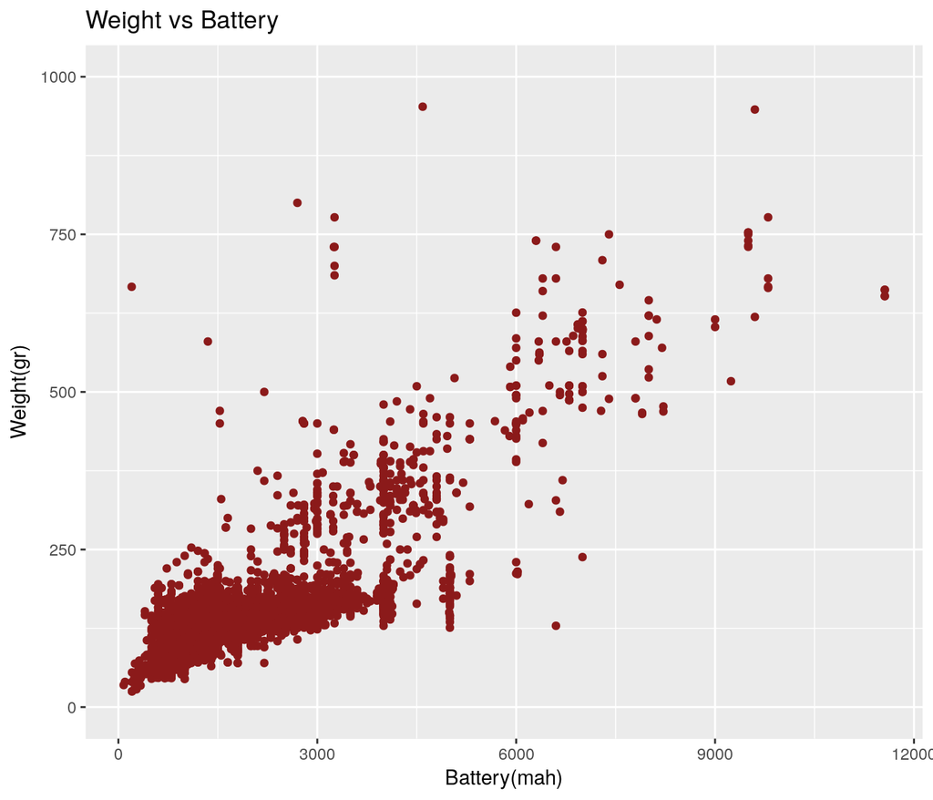

```r
p=ggplot(data = mobile_data , aes(x=battery_mah,y=weight))
p+geom_point(colour="firebrick4")+xlab("Battery(mah)")+ylab("Weight(gr)")+
  ggtitle("Weight vs Battery")+ylim(c(0,1000))
```

```r
idx_na=!is.na(mobile_data$battery_mah)
idx_na= idx_na & !is.na(mobile_data$weight)

cor(x=mobile_data$battery_mah[idx_na],y=mobile_data$weight[idx_na])
```

```
## [1] 0.8086273
```

۹. قیمت پرچمداران یک برند خاص مثلا سامسونگ را بیابید و نمودار قیمت زمان و نام مدل را رسم نمایید.

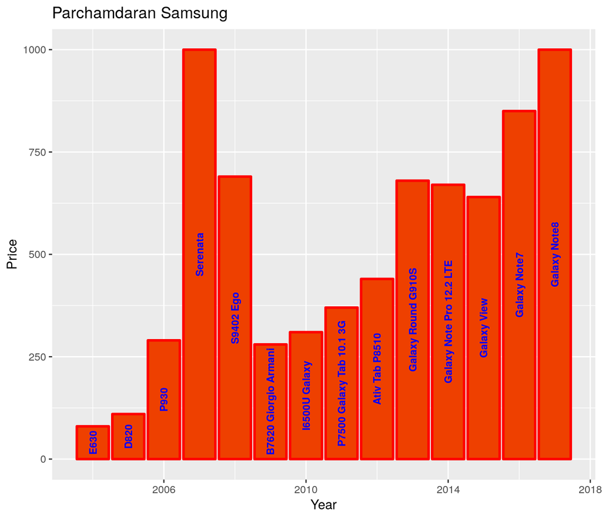

```r
idx_na=!is.na(mobile_data$price)

mobile_data[idx_na,] %>%
  filter(company=="Samsung") %>%
  group_by(year) %>%
  summarise(topPrice=price[which.max(price)],topDevice=device[which.max(price)]) -> flag

p=ggplot(data=flag , aes(x=year,y=topPrice))
p+geom_bar(stat="identity",fill="orangered2",color="red",size=1)+
  xlab("Year")+ylab("Price")+ggtitle("Parchamdaran Samsung")+
  geom_text(aes(label = topDevice) ,color="blue" ,angle=90,size=3,
            fontface = "bold",position = position_stack(vjust = 0.5))
```

اولین نمودار جالب:

در این نمودار متوسط قیمت گوشی های هفت کمپانی مطرح در طول تاریخ نشان داده شده است.

در این نمودار سعی شده است با حذف قیمت های پرت گرایش کلی کمپانی ها در قیمت گذاری را مشاهده کنیم.

شرکت اپل گران ترین گوشی ها را تولید می کند.

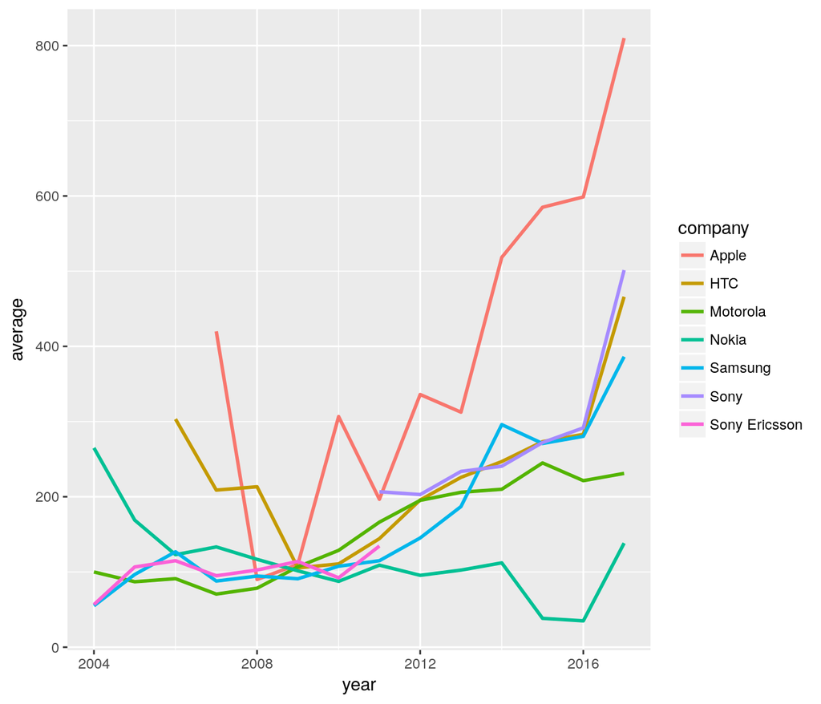

```r
mobile_data %>%
  group_by(company,year) %>%
  filter(grepl("Samsung|Nokia|Sony|Apple|HTC|Motorola|Sony Ericsson",company)) %>%
  summarise(average=mean(price,trim=0.2,na.rm=T)) -> stat


p=ggplot(data=stat,aes(x=year,y=average,color=company))
p+geom_line(size=1)+xlim(c(2004,2017))
```

دومین نمودار جالب:

در این هیستوگرام مشاهده می شود که سیستم عامل اندروید با اختلاف فاحشی از بقیه سیستم عامل ها بیشتر مورد استفاده قرار می گیرد.

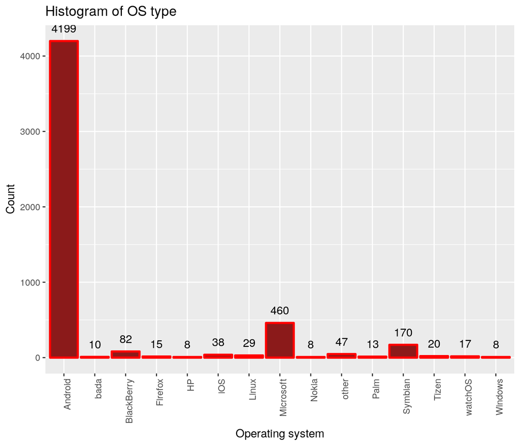

```r
idx_na=!is.na(mobile_data$os_type)

p=ggplot(data=mobile_data[idx_na,],aes(x=os_type))
p+geom_histogram(stat="count",fill="firebrick4",colour="red",size=1)+
  xlab("Operating system")+ylab("Count")+ggtitle("Histogram of OS type ")+
  theme(axis.text.x = element_text(angle = 90, hjust = 1))+
  stat_count(aes(y=..count..,label=..count..),geom="text",vjust=-1)
```

سومین نمودار جالب:

در این نمودار می خواهیم بررسی کنیم آیا پرچم داران شرکت سامسونگ از بین گوشی هایی با سایز بزرگ انتخاب می شوند با خیر؟

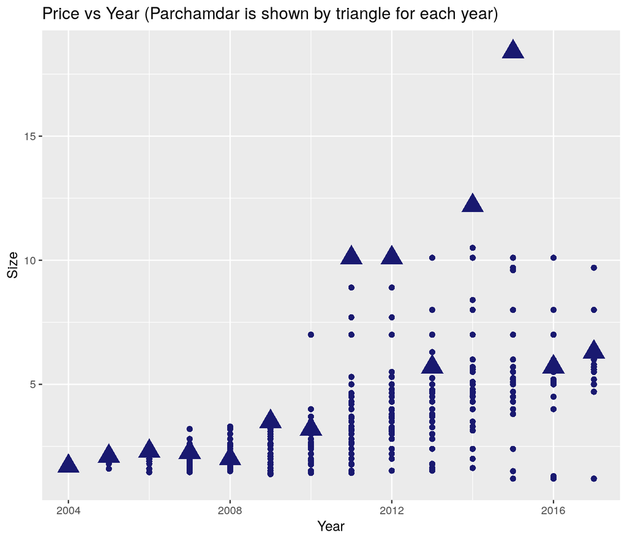

```r
idx_na=!is.na(mobile_data$price)

mobile_data[idx_na,] %>%
  filter(company=="Samsung") -> case
case %>%
  group_by(year) %>%
  summarise(topDevice=device[which.max(price)]) -> flag

case$flag="No"
idx = case$device %in% flag$topDevice
case$flag[idx]="Yes"


p=ggplot(data=case , aes(x=year,y=display_size,size=flag,shape=flag))
p+geom_point(colour="midnightblue")+xlab("Year")+ylab("Size")+
  theme(legend.position="none")+
  ggtitle("Price vs Year (Parchamdar is shown by triangle for each year)")
```